```python
from sympy import*
from IPython.display import Image, display, HTML
from scipy import optimize
import matplotlib.pyplot as plt
import numpy as np
```

# 1. Position Kinematics - Panda

First I completed the DH methode with the Khalil convention, I am used to this and it makes more sense for me. I'll be able to check my results as well at the end.

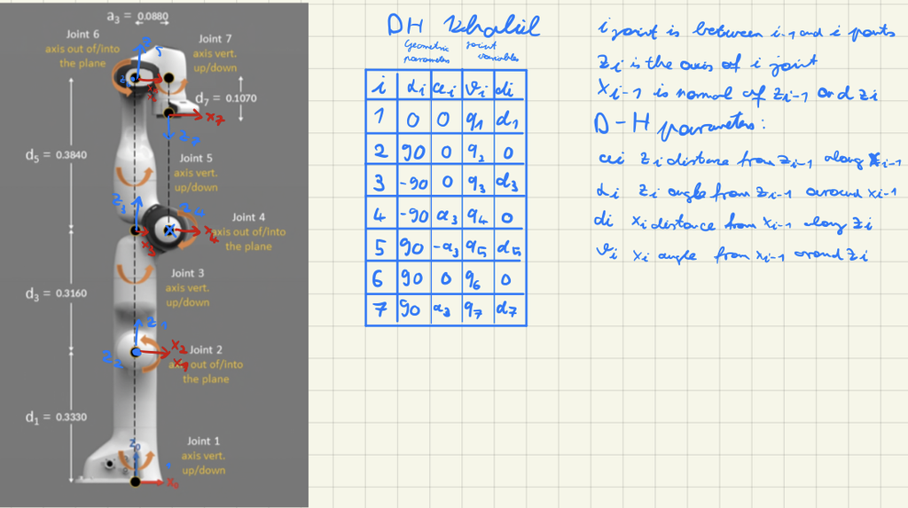

```python
Image("Panda_K.png")
```

```python
def DH_Tr_sym(alpha=0, a=0, theta=0, d=0):
    Tr_alpha=Matrix([[1,0,0,0],
                       [0,cos(alpha),-sin(alpha),0],
                       [0,sin(alpha) ,cos(alpha),0],
                       [0,0,0,1]])
    Tr_a=Matrix([[1,0,0,a],
                   [0,1,0,0],
                   [0,0,1,0],
                   [0,0,0,1]])
    Tr_theta=Matrix([[cos(theta),-sin(theta),0,0],
                       [sin(theta),cos(theta),0,0],
                       [0,0,1,0],
                       [0,0,0,1]])
    Tr_d=Matrix([[1,0,0,0],
                   [0,1,0,0],
                   [0,0,1,d],
                   [0,0,0,1]])
    Tr_KHALIL=Tr_alpha@Tr_a@Tr_theta@Tr_d

    return Tr_KHALIL
```

```python
q1,q2,q3,q4,q5,q6,q7,d1,d3,d5,d7,a3=symbols('q_1 q_2 q_3 q_4 q_5 q_6 q_7 d_1 d_3 d_5 d_7 a_3')
```

```python
T_01=simplify(DH_Tr_sym(alpha=0, a=0, theta=q1, d=d1))
```

```python
T_12=simplify(DH_Tr_sym(alpha=pi/2, a=0, theta=q2, d=0))
```

```python
T_23=simplify(DH_Tr_sym(alpha=-pi/2, a=0, theta=q3, d=d3))
```

```python
T_34=simplify(DH_Tr_sym(alpha=-pi/2, a=a3, theta=q4, d=0))
```

```python
T_45=simplify(DH_Tr_sym(alpha=pi/2, a=-a3, theta=q5, d=d5))
```

```python
T_56=simplify(DH_Tr_sym(alpha=pi/2, a=0, theta=q6, d=0))
```

```python
T_67=simplify(DH_Tr_sym(alpha=pi/2, a=a3, theta=q7, d=d7))
```

```python
T_07=T_01@T_12@T_23@T_34@T_45@T_56@T_67
T_07
```

$\displaystyle \left[\begin{matrix}\left(\left(\left(\left(- \sin{\left(q_{1} \right)} \sin{\left(q_{3} \right)} + \cos{\left(q_{1} \right)} \cos{\left(q_{2} \right)} \cos{\left(q_{3} \right)}\right) \cos{\left(q_{4} \right)} + \sin{\left(q_{2} \right)} \sin{\left(q_{4} \right)} \cos{\left(q_{1} \right)}\right) \cos{\left(q_{5} \right)} + \left(- \sin{\left(q_{1} \right)} \cos{\left(q_{3} \right)} - \sin{\left(q_{3} \right)} \cos{\left(q_{1} \right)} \cos{\left(q_{2} \right)}\right) \sin{\left(q_{5} \right)}\right) \cos{\left(q_{6} \right)} + \left(\left(- \sin{\left(q_{1} \right)} \sin{\left(q_{3} \right)} + \cos{\left(q_{1} \right)} \cos{\left(q_{2} \right)} \cos{\left(q_{3} \right)}\right) \sin{\left(q_{4} \right)} - \sin{\left(q_{2} \right)} \cos{\left(q_{1} \right)} \cos{\left(q_{4} \right)}\right) \sin{\left(q_{6} \right)}\right) \cos{\left(q_{7} \right)} + \left(\left(\left(- \sin{\left(q_{1} \right)} \sin{\left(q_{3} \right)} + \cos{\left(q_{1} \right)} \cos{\left(q_{2} \right)} \cos{\left(q_{3} \right)}\right) \cos{\left(q_{4} \right)} + \sin{\left(q_{2} \right)} \sin{\left(q_{4} \right)} \cos{\left(q_{1} \right)}\right) \sin{\left(q_{5} \right)} - \left(- \sin{\left(q_{1} \right)} \cos{\left(q_{3} \right)} - \sin{\left(q_{3} \right)} \cos{\left(q_{1} \right)} \cos{\left(q_{2} \right)}\right) \cos{\left(q_{5} \right)}\right) \sin{\left(q_{7} \right)} & - \left(\left(\left(\left(- \sin{\left(q_{1} \right)} \sin{\left(q_{3} \right)} + \cos{\left(q_{1} \right)} \cos{\left(q_{2} \right)} \cos{\left(q_{3} \right)}\right) \cos{\left(q_{4} \right)} + \sin{\left(q_{2} \right)} \sin{\left(q_{4} \right)} \cos{\left(q_{1} \right)}\right) \cos{\left(q_{5} \right)} + \left(- \sin{\left(q_{1} \right)} \cos{\left(q_{3} \right)} - \sin{\left(q_{3} \right)} \cos{\left(q_{1} \right)} \cos{\left(q_{2} \right)}\right) \sin{\left(q_{5} \right)}\right) \cos{\left(q_{6} \right)} + \left(\left(- \sin{\left(q_{1} \right)} \sin{\left(q_{3} \right)} + \cos{\left(q_{1} \right)} \cos{\left(q_{2} \right)} \cos{\left(q_{3} \right)}\right) \sin{\left(q_{4} \right)} - \sin{\left(q_{2} \right)} \cos{\left(q_{1} \right)} \cos{\left(q_{4} \right)}\right) \sin{\left(q_{6} \right)}\right) \sin{\left(q_{7} \right)} + \left(\left(\left(- \sin{\left(q_{1} \right)} \sin{\left(q_{3} \right)} + \cos{\left(q_{1} \right)} \cos{\left(q_{2} \right)} \cos{\left(q_{3} \right)}\right) \cos{\left(q_{4} \right)} + \sin{\left(q_{2} \right)} \sin{\left(q_{4} \right)} \cos{\left(q_{1} \right)}\right) \sin{\left(q_{5} \right)} - \left(- \sin{\left(q_{1} \right)} \cos{\left(q_{3} \right)} - \sin{\left(q_{3} \right)} \cos{\left(q_{1} \right)} \cos{\left(q_{2} \right)}\right) \cos{\left(q_{5} \right)}\right) \cos{\left(q_{7} \right)} & \left(\left(\left(- \sin{\left(q_{1} \right)} \sin{\left(q_{3} \right)} + \cos{\left(q_{1} \right)} \cos{\left(q_{2} \right)} \cos{\left(q_{3} \right)}\right) \cos{\left(q_{4} \right)} + \sin{\left(q_{2} \right)} \sin{\left(q_{4} \right)} \cos{\left(q_{1} \right)}\…

Second I completed the DH methode with the Sponge convention.

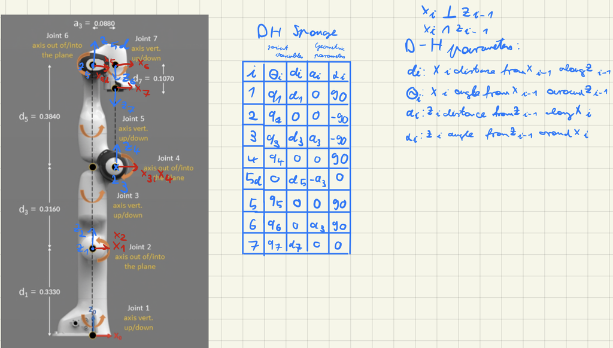

```python
Image("Panda_S.png")
```

```python
def DH_Tr_sym_UMD(theta=0, d=0 , a=0, alpha=0):
    Tr_theta=Matrix([[cos(theta),-sin(theta),0,0],
                       [sin(theta),cos(theta),0,0],
                       [0,0,1,0],
                       [0,0,0,1]])
    Tr_d=Matrix([[1,0,0,0],
                   [0,1,0,0],
                   [0,0,1,d],
                   [0,0,0,1]])
    Tr_a=Matrix([[1,0,0,a],
                   [0,1,0,0],
                   [0,0,1,0],
                   [0,0,0,1]])
    Tr_alpha=Matrix([[1,0,0,0],
                       [0,cos(alpha),-sin(alpha),0],
                       [0,sin(alpha) ,cos(alpha),0],
                       [0,0,0,1]])


    Tr_KHALIL=Tr_theta@Tr_d@Tr_a@Tr_alpha

    return Tr_KHALIL
```

```python
H_01=DH_Tr_sym_UMD(theta=q1, d=d1 , a=0, alpha=pi/2)
H_01
```

$\displaystyle \left[\begin{matrix}\cos{\left(q_{1} \right)} & 0 & \sin{\left(q_{1} \right)} & 0\\\sin{\left(q_{1} \right)} & 0 & - \cos{\left(q_{1} \right)} & 0\\0 & 1 & 0 & d_{1}\\0 & 0 & 0 & 1\end{matrix}\right]$

```python
H_12=DH_Tr_sym_UMD(theta=q2, d=0 , a=0, alpha=-pi/2)
H_12
```

$\displaystyle \left[\begin{matrix}\cos{\left(q_{2} \right)} & 0 & - \sin{\left(q_{2} \right)} & 0\\\sin{\left(q_{2} \right)} & 0 & \cos{\left(q_{2} \right)} & 0\\0 & -1 & 0 & 0\\0 & 0 & 0 & 1\end{matrix}\right]$

```python
H_23=DH_Tr_sym_UMD(theta=q3, d=d3 , a=a3, alpha=-pi/2)
H_23
```

$\displaystyle \left[\begin{matrix}\cos{\left(q_{3} \right)} & 0 & - \sin{\left(q_{3} \right)} & a_{3} \cos{\left(q_{3} \right)}\\\sin{\left(q_{3} \right)} & 0 & \cos{\left(q_{3} \right)} & a_{3} \sin{\left(q_{3} \right)}\\0 & -1 & 0 & d_{3}\\0 & 0 & 0 & 1\end{matrix}\right]$

```python
H_34=DH_Tr_sym_UMD(theta=q4, d=0 , a=0, alpha=pi/2)
H_34
```

$\displaystyle \left[\begin{matrix}\cos{\left(q_{4} \right)} & 0 & \sin{\left(q_{4} \right)} & 0\\\sin{\left(q_{4} \right)} & 0 & - \cos{\left(q_{4} \right)} & 0\\0 & 1 & 0 & 0\\0 & 0 & 0 & 1\end{matrix}\right]$

```python
H_45d=DH_Tr_sym_UMD(theta=0, d=d5 , a=-a3, alpha=0)
H_45d
```

$\displaystyle \left[\begin{matrix}1 & 0 & 0 & - a_{3}\\0 & 1 & 0 & 0\\0 & 0 & 1 & d_{5}\\0 & 0 & 0 & 1\end{matrix}\right]$

```python
H_5d5=DH_Tr_sym_UMD(theta=q5, d=0 , a=0, alpha=pi/2)
H_5d5
```

$\displaystyle \left[\begin{matrix}\cos{\left(q_{5} \right)} & 0 & \sin{\left(q_{5} \right)} & 0\\\sin{\left(q_{5} \right)} & 0 & - \cos{\left(q_{5} \right)} & 0\\0 & 1 & 0 & 0\\0 & 0 & 0 & 1\end{matrix}\right]$

```python
H_56=DH_Tr_sym_UMD(theta=q6, d=0 , a=a3, alpha=pi/2)
H_56
```

$\displaystyle \left[\begin{matrix}\cos{\left(q_{6} \right)} & 0 & \sin{\left(q_{6} \right)} & a_{3} \cos{\left(q_{6} \right)}\\\sin{\left(q_{6} \right)} & 0 & - \cos{\left(q_{6} \right)} & a_{3} \sin{\left(q_{6} \right)}\\0 & 1 & 0 & 0\\0 & 0 & 0 & 1\end{matrix}\right]$

```python
H_67=DH_Tr_sym_UMD(theta=q7, d=d7 , a=0, alpha=0)
H_67
```

$\displaystyle \left[\begin{matrix}\cos{\left(q_{7} \right)} & - \sin{\left(q_{7} \right)} & 0 & 0\\\sin{\left(q_{7} \right)} & \cos{\left(q_{7} \right)} & 0 & 0\\0 & 0 & 1 & d_{7}\\0 & 0 & 0 & 1\end{matrix}\right]$

```python
H_07=H_01@H_12@H_23@H_34@H_45d@H_5d5@H_56@H_67
H_07
```

$\displaystyle \left[\begin{matrix}\left(\left(\left(\left(- \sin{\left(q_{1} \right)} \sin{\left(q_{3} \right)} + \cos{\left(q_{1} \right)} \cos{\left(q_{2} \right)} \cos{\left(q_{3} \right)}\right) \cos{\left(q_{4} \right)} + \sin{\left(q_{2} \right)} \sin{\left(q_{4} \right)} \cos{\left(q_{1} \right)}\right) \cos{\left(q_{5} \right)} + \left(- \sin{\left(q_{1} \right)} \cos{\left(q_{3} \right)} - \sin{\left(q_{3} \right)} \cos{\left(q_{1} \right)} \cos{\left(q_{2} \right)}\right) \sin{\left(q_{5} \right)}\right) \cos{\left(q_{6} \right)} + \left(\left(- \sin{\left(q_{1} \right)} \sin{\left(q_{3} \right)} + \cos{\left(q_{1} \right)} \cos{\left(q_{2} \right)} \cos{\left(q_{3} \right)}\right) \sin{\left(q_{4} \right)} - \sin{\left(q_{2} \right)} \cos{\left(q_{1} \right)} \cos{\left(q_{4} \right)}\right) \sin{\left(q_{6} \right)}\right) \cos{\left(q_{7} \right)} + \left(\left(\left(- \sin{\left(q_{1} \right)} \sin{\left(q_{3} \right)} + \cos{\left(q_{1} \right)} \cos{\left(q_{2} \right)} \cos{\left(q_{3} \right)}\right) \cos{\left(q_{4} \right)} + \sin{\left(q_{2} \right)} \sin{\left(q_{4} \right)} \cos{\left(q_{1} \right)}\right) \sin{\left(q_{5} \right)} - \left(- \sin{\left(q_{1} \right)} \cos{\left(q_{3} \right)} - \sin{\left(q_{3} \right)} \cos{\left(q_{1} \right)} \cos{\left(q_{2} \right)}\right) \cos{\left(q_{5} \right)}\right) \sin{\left(q_{7} \right)} & - \left(\left(\left(\left(- \sin{\left(q_{1} \right)} \sin{\left(q_{3} \right)} + \cos{\left(q_{1} \right)} \cos{\left(q_{2} \right)} \cos{\left(q_{3} \right)}\right) \cos{\left(q_{4} \right)} + \sin{\left(q_{2} \right)} \sin{\left(q_{4} \right)} \cos{\left(q_{1} \right)}\right) \cos{\left(q_{5} \right)} + \left(- \sin{\left(q_{1} \right)} \cos{\left(q_{3} \right)} - \sin{\left(q_{3} \right)} \cos{\left(q_{1} \right)} \cos{\left(q_{2} \right)}\right) \sin{\left(q_{5} \right)}\right) \cos{\left(q_{6} \right)} + \left(\left(- \sin{\left(q_{1} \right)} \sin{\left(q_{3} \right)} + \cos{\left(q_{1} \right)} \cos{\left(q_{2} \right)} \cos{\left(q_{3} \right)}\right) \sin{\left(q_{4} \right)} - \sin{\left(q_{2} \right)} \cos{\left(q_{1} \right)} \cos{\left(q_{4} \right)}\right) \sin{\left(q_{6} \right)}\right) \sin{\left(q_{7} \right)} + \left(\left(\left(- \sin{\left(q_{1} \right)} \sin{\left(q_{3} \right)} + \cos{\left(q_{1} \right)} \cos{\left(q_{2} \right)} \cos{\left(q_{3} \right)}\right) \cos{\left(q_{4} \right)} + \sin{\left(q_{2} \right)} \sin{\left(q_{4} \right)} \cos{\left(q_{1} \right)}\right) \sin{\left(q_{5} \right)} - \left(- \sin{\left(q_{1} \right)} \cos{\left(q_{3} \right)} - \sin{\left(q_{3} \right)} \cos{\left(q_{1} \right)} \cos{\left(q_{2} \right)}\right) \cos{\left(q_{5} \right)}\right) \cos{\left(q_{7} \right)} & \left(\left(\left(- \sin{\left(q_{1} \right)} \sin{\left(q_{3} \right)} + \cos{\left(q_{1} \right)} \cos{\left(q_{2} \right)} \cos{\left(q_{3} \right)}\right) \cos{\left(q_{4} \right)} + \sin{\left(q_{2} \right)} \sin{\left(q_{4} \right)} \cos{\left(q_{1} \right)}\…

I compared the two results, they are giving the same answers, so it seems fine

```python
T_07.subs({q1:pi,q2:pi/2,q3:pi,q4:pi/2,q5:pi,q6:pi/2,q7:pi})
```

$\displaystyle \left[\begin{matrix}0 & 0 & 1 & a_{3} + d_{3} + d_{7}\\0 & -1 & 0 & 0\\1 & 0 & 0 & - 2 a_{3} + d_{1} - d_{5}\\0 & 0 & 0 & 1\end{matrix}\right]$

```python
H_07.subs({q1:pi,q2:pi/2,q3:pi,q4:pi/2,q5:pi,q6:pi/2,q7:pi})
```

$\displaystyle \left[\begin{matrix}0 & 0 & 1 & a_{3} + d_{3} + d_{7}\\0 & -1 & 0 & 0\\1 & 0 & 0 & - 2 a_{3} + d_{1} - d_{5}\\0 & 0 & 0 & 1\end{matrix}\right]$

In tha last step I completed the five known configuration.

Testing with known configutation. Let $d_1,d_3,d_5=1$ and $d_7,a_3=0.5$

First test the configuration according to the initial pose, means, all angles are 0. Output should be at $x=0.5,y=0,z=2.5$ with orientation $x=x,y=-y,z=-z$

```python
H_07.subs({q1:0,q2:0,q3:0,q4:0,q5:0,q6:0,q7:0,d1:1,d3:1,d5:1,d7:0.5,a3:0.5})
```

$\displaystyle \left[\begin{matrix}1 & 0 & 0 & 0.5\\0 & -1 & 0 & 0\\0 & 0 & -1 & 2.5\\0 & 0 & 0 & 1\end{matrix}\right]$

Second test the configuration with $q_7=90 deg$ Output should be at $x=0.5,y=0,z=2.5$ with orientation $x=-y,y=-x,z=-z$

```python
H_07.subs({q1:0,q2:0,q3:0,q4:0,q5:0,q6:0,q7:pi/2,d1:1,d3:1,d5:1,d7:0.5,a3:0.5})
```

$\displaystyle \left[\begin{matrix}0 & -1 & 0 & 0.5\\-1 & 0 & 0 & 0\\0 & 0 & -1 & 2.5\\0 & 0 & 0 & 1\end{matrix}\right]$

Third test the configuration with $q_5=-90 deg$ and $q_7=-90 deg$ Output should be at $x=0,y=-0.5,z=2.5$ with orientation $x=x,y=-y,z=-z$

```python
H_07.subs({q1:0,q2:0,q3:0,q4:0,q5:-pi/2,q6:0,q7:-pi/2,d1:1,d3:1,d5:1,d7:0.5,a3:0.5})
```

$\displaystyle \left[\begin{matrix}1 & 0 & 0 & 0\\0 & -1 & 0 & -0.5\\0 & 0 & -1 & 2.5\\0 & 0 & 0 & 1\end{matrix}\right]$

```python
H_07.subs({q1:pi/2,q2:0,q3:-pi/2,q4:pi/2,q5:0,q6:0,q7:0,d1:1,d3:1,d5:1,d7:0.5,a3:0.5})
```

$\displaystyle \left[\begin{matrix}0 & 0 & -1 & 1.0\\0 & -1 & 0 & 0\\-1 & 0 & 0 & 2.0\\0 & 0 & 0 & 1\end{matrix}\right]$

Fifth test the configuration with $q_2=-90 deg$ and $q_6=270deg$ Output should be at $x=1.5,y=0,z=1.5$ with orientation $x=-x,y=-y,z=z$

```python
H_07.subs({q1:0,q2:-pi/2,q3:0,q4:0,q5:0,q6:1.5*pi,q7:0,d1:1,d3:1,d5:1,d7:0.5,a3:0.5})
```

$\displaystyle \left[\begin{matrix}-1 & 0 & 0 & 1.5\\0 & -1 & 0 & 0\\0 & 0 & 1 & 1.5\\0 & 0 & 0 & 1\end{matrix}\right]$

# 2. Position Kinematics - KUKA

See the table and the drawing below.

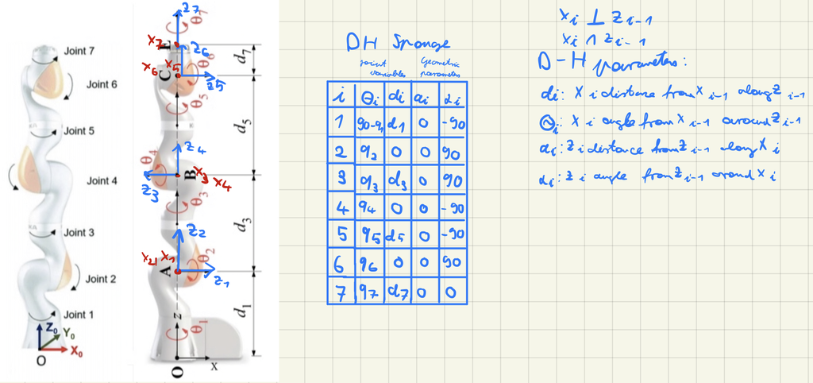

```python
Image("KUKA.png")
```